# Exercise 8 Group A

Mia McReynolds, Eli Polzer, Matt Futia

09 March 2021

```r
# some pathnames; yours will be specific to your CPU !!
  path.root <- "~/University of Vermont/Classes/sdhmR/sdhmR-V2021.1"
  path.mod2 <- paste(path.root, "/data/module02", sep = "")
  path.mod5.2 <- paste(path.root, "/data/module05.02-GAM", sep = "")
  path.figs <- paste(path.root, "/powerpoints/figures", sep = "")
  path.gis <- paste(path.root, "/data/gis_layers", sep = "")

# some libraries
  library(tidyverse)
  library(PresenceAbsence)  # fxns: optimal.thresholds, presence.absence.accuracy,
                            #       auc.roc.plot
  library(DAAG)
  library(raster)
  library(car)
  library(gam)
  library(sf)
```

## Question #1

- Import and explore data
  - **NOTE**: intent is not to reduce number of variables; that was completed in exercise #5. Rather, calculate simple descriptive statistics (mean, sd, n) and boxplots

```r
# load range-wide training data
load("~/University of Vermont/Classes/sdhmR/sdhmR-V2021.1/data/module02/tr_RANG.Rdata")

str(tr_RANG)
```

```
## 'data.frame':    5997 obs. of  11 variables:
##  $ FNETID    : num  9270 13732 22606 24072 40340 ...
##  $ RANG106   : num  0 0 0 0 0 0 0 0 0 0 ...
##  $ tr.wgs_x  : num  -111 -111 -111 -111 -111 ...
##  $ tr.wgs_y  : num  42.1 42.1 42 42 41.9 ...
##  $ etpt_5    : num  88 85 88 85 88 79 85 75 88 87 ...
##  $ mind_yr_av: num  -1105 -1008 -1141 -1025 -1153 ...
##  $ prad_sw_di: num  12163 12285 12079 12120 12181 ...
##  $ prec_w_hal: num  25.7 27.2 19.8 27.2 18.2 ...
##  $ rough_1k  : num  1.66 16.45 11.39 12.19 1.19 ...
##  $ tmax_s_hal: num  224 201 218 201 221 ...
##  $ topos     : num  -89.9 16.8 -46.7 22.7 -30.8 ...
```

```r
#pivot for ggplotting/summary
tr_RANG_long <- tr_RANG %>%
  pivot_longer(etpt_5:topos, names_to = "Variable", values_to = "Value")

tr_RANG_long %>% group_by(Variable) %>%
  summarise(n = n(),
            mean = mean(Value),
            sd = sd(Value),
            min = min(Value),
            max = max(Value))
```

```
## # A tibble: 7 x 6
##   Variable       n     mean     sd      min    max
##   <chr>      <int>    <dbl>  <dbl>    <dbl>  <dbl>
## 1 etpt_5      5997    91.6    7.30     0       99
## 2 mind_yr_av  5997 -1400.   323.   -2065.     153.
## 3 prad_sw_di  5997 10929.   684.    8070.   13026.
## 4 prec_w_hal  5997    26.1   13.1      6.33   130.
## 5 rough_1k    5997    17.3   15.7      0      130.
## 6 tmax_s_hal  5997   249.    38.5     87.8    368.
## 7 topos       5997     1.55  48.7   -209.     334
```

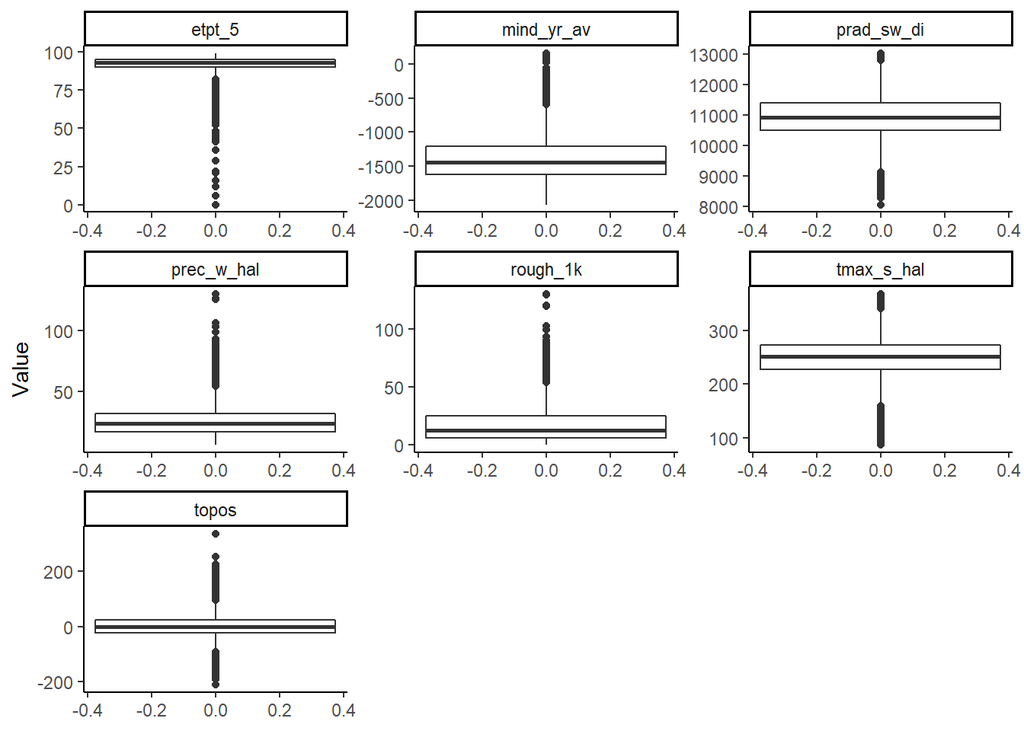

```r
#boxplot
ggplot(tr_RANG_long, aes(y=Value)) +
  geom_boxplot() +
  facet_wrap(~Variable, scales="free") +
  theme_classic()
```

I used the same methods as in Exercise 7.

## Question #2

- Construct some basic plots to assess possible relationships warranting use of a GAM
- List which variables may be amenable to a GAM–based smoother

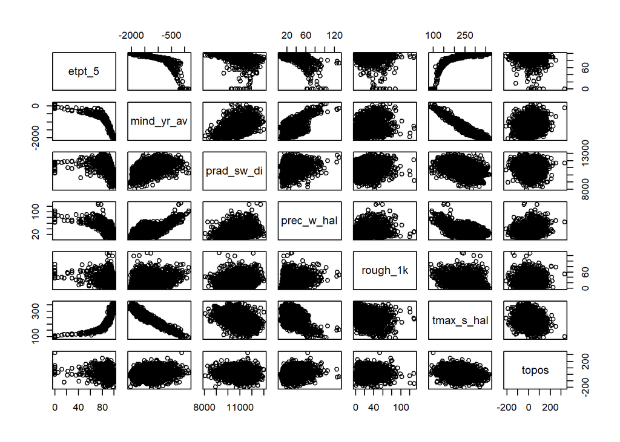

```r
plot(tr_RANG[5:11])
```

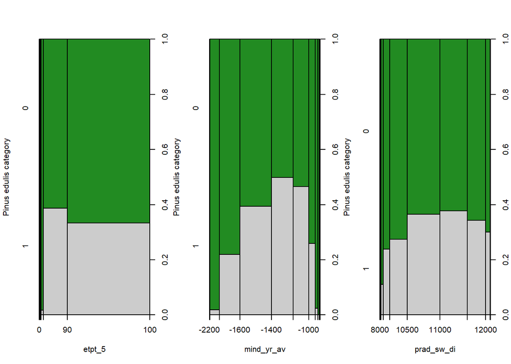

```r
# factor plots - part 1

  par(mfcol = c(1, 3)) # if desired
  col.list <- c("grey80", "forestgreen") # specified color ramp
  plot(as.factor(tr_RANG$RANG106) ~ tr_RANG$etpt_5, xlab = "etpt_5", ylab = "Pinus edulis category",
    col = col.list)
  plot(as.factor(tr_RANG$RANG106) ~ tr_RANG$mind_yr_av, xlab = "mind_yr_av",
    ylab = "Pinus edulis category", col = col.list)
  plot(as.factor(tr_RANG$RANG106) ~ tr_RANG$prad_sw_di, xlab = "prad_sw_di", ylab = "Pinus edulis category",
    col = col.list)
```

```r
  par(mfrow = c(1, 1))
```

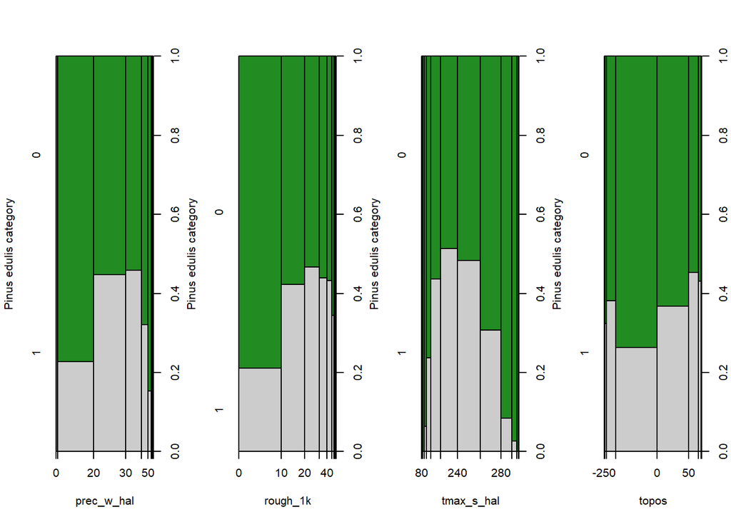

```r
# factor plots - part 2
  par(mfcol = c(1, 4)) # if desired
  col.list <- c("grey80", "forestgreen") # specified color ramp
  plot(as.factor(tr_RANG$RANG106) ~ tr_RANG$prec_w_hal, xlab = "prec_w_hal", ylab = "Pinus edulis category",
    col = col.list)
  plot(as.factor(tr_RANG$RANG106) ~ tr_RANG$rough_1k, xlab = "rough_1k",
    ylab = "Pinus edulis category", col = col.list)
  plot(as.factor(tr_RANG$RANG106) ~ tr_RANG$tmax_s_hal, xlab = "tmax_s_hal", ylab = "Pinus edulis category",
    col = col.list)
  plot(as.factor(tr_RANG$RANG106) ~ tr_RANG$topos, xlab = "topos", ylab = "Pinus edulis category",
    col = col.list)
```

```r
  par(mfrow = c(1, 1))
```

Based on these plots, it appears that many variables could be best fit using a smoother, since they have several different “sections” with differing slopes. Only etpt_5 seems linear. Variables to examine further for GAM smoothers: * mind_yr_av * prad_sw_di * prec_w_hal * rough_1k * tmax_s_hal * topos

Some of these look like they would only benefit from a smoother at extreme values, so it will be important to examine the cost/benefit to the model fit of smoothing these.

## Question #3

- Construct a set of GAMs from fully linear to a maximum of 5 splines
  - Use lowess smoother rather than default spline –> UPDATE: use default splines!

```r
# GAM model 0: all linear
# alternative linear model using gam call
  mod0.GAM_RANGE <- gam(RANG106 ~ etpt_5 + mind_yr_av + prad_sw_di + prec_w_hal + rough_1k + tmax_s_hal + topos,
    family = binomial, data = tr_RANG)
  summary(mod0.GAM_RANGE) # model #0 summary
```

```
##
## Call: gam(formula = RANG106 ~ etpt_5 + mind_yr_av + prad_sw_di + prec_w_hal +
##     rough_1k + tmax_s_hal + topos, family = binomial, data = tr_RANG)
## Deviance Residuals:
##     Min      1Q  Median      3Q     Max
## -2.2164 -0.8752 -0.5815  1.1258  2.4109
##
## (Dispersion Parameter for binomial family taken to be 1)
##
##     Null Deviance: 7634.351 on 5996 degrees of freedom
## Residual Deviance: 6660.565 on 5989 degrees of freedom
## AIC: 6676.565
##
## Number of Local Scoring Iterations: 6
##
## Anova for Parametric Effects
##              Df Sum Sq Mean Sq  F value    Pr(>F)
## etpt_5        1   24.6   24.57  26.5299 2.678e-07 ***
## mind_yr_av    1  133.7  133.71 144.3659 < 2.2e-16 ***
## prad_sw_di    1    2.1    2.14   2.3057   0.12895
## prec_w_hal    1    0.5    0.48   0.5237   0.46932
## rough_1k      1  109.4  109.43 118.1537 < 2.2e-16 ***
## tmax_s_hal    1  403.9  403.94 436.1451 < 2.2e-16 ***
## topos         1    3.4    3.44   3.7195   0.05383 .
## Residuals  5989 5546.8    0.93
## ---
## Signif. codes:  0 '***' 0.001 '**' 0.01 '*' 0.05 '.' 0.1 ' ' 1
```

```r
# GAM model 1: 2 smoothers
mod1.GAM_RANGE <- gam(RANG106 ~ etpt_5 + s(mind_yr_av, 2) + s(prad_sw_di, 2) + s(prec_w_hal, 2) + s(rough_1k, 2) + s(tmax_s_hal, 2) + s(topos, 2), family = binomial, data = tr_RANG)

summary(mod1.GAM_RANGE)
```

```
##
## Call: gam(formula = RANG106 ~ etpt_5 + s(mind_yr_av, 2) + s(prad_sw_di,
##     2) + s(prec_w_hal, 2) + s(rough_1k, 2) + s(tmax_s_hal, 2) +
##     s(topos, 2), family = binomial, data = tr_RANG)
## Deviance Residuals:
##     Min      1Q  Median      3Q     Max
## -2.0020 -0.8640 -0.4365  1.0336  2.6273
##
## (Dispersion Parameter for binomial family taken to be 1)
##
##     Null Deviance: 7634.351 on 5996 degrees of freedom
## Residual Deviance: 5996.665 on 5983 degrees of freedom
## AIC: 6024.665
##
## Number of Local Scoring Iterations: NA
##
## Anova for Parametric Effects
##                    Df Sum Sq Mean Sq  F value    Pr(>F)
## etpt_5              1   16.4  16.393  20.1077 7.457e-06 ***
## s(mind_yr_av, 2)    1    7.0   6.990   8.5741  0.003423 **
## s(prad_sw_di, 2)    1    5.7   5.657   6.9383  0.008459 **
## s(prec_w_hal, 2)    1   20.9  20.889  25.6225 4.276e-07 ***
## s(rough_1k, 2)      1  141.3 141.286 173.3011 < 2.2e-16 ***
## s(tmax_s_hal, 2)    1  143.4 143.369 175.8566 < 2.2e-16 ***
## s(topos, 2)         1    5.8   5.823   7.1422  0.007549 **
## Residuals        5983 4877.7   0.815
## ---
## Signif. codes:  0 '***' 0.001 '**' 0.01 '*' 0.05 '.' 0.1 ' ' 1
##
## Anova for Nonparametric Effects
##                  Npar Df Npar Chisq    P(Chi)
## (Intercept)
## etpt_5
## s(mind_yr_av, 2)       1     76.093 < 2.2e-16 ***
## s(prad_sw_di, 2)       1     12.298 0.0004535 ***
## s(prec_w_hal, 2)       1    122.871 < 2.2e-16 ***
## s(rough_1k, 2)         1    130.108 < 2.2e-16 ***
## s(tmax_s_hal, 2)       1    169.610 < 2.2e-16 ***
## s(topos, 2)            1      3.724 0.0536162 .
## ---
## Signif. codes:  0 '***' 0.001 '**' 0.01 '*' 0.05 '.' 0.1 ' ' 1
```

I only used smoothers on the variables listed above, not etpt_5.

```r
# GAM model 2: smoothers=3
mod2.GAM_RANGE <- gam(RANG106 ~ etpt_5 + s(mind_yr_av,3) + s(prad_sw_di,3) + s(prec_w_hal,3) + s(rough_1k,3) + s(tmax_s_hal,3) + s(topos,3), family = binomial, data = tr_RANG)

summary(mod2.GAM_RANGE) # model #2 summary
```

```
##
## Call: gam(formula = RANG106 ~ etpt_5 + s(mind_yr_av, 3) + s(prad_sw_di,
##     3) + s(prec_w_hal, 3) + s(rough_1k, 3) + s(tmax_s_hal, 3) +
##     s(topos, 3), family = binomial, data = tr_RANG)
## Deviance Residuals:
##     Min      1Q  Median      3Q     Max
## -1.9721 -0.8538 -0.3623  0.9782  2.8071
##
## (Dispersion Parameter for binomial family taken to be 1)
##
##     Null Deviance: 7634.351 on 5996 degrees of freedom
## Residual Deviance: 5862.103 on 5977 degrees of freedom
## AIC: 5902.103
##
## Number of Local Scoring Iterations: NA
##
## Anova for Parametric Effects
##                    Df Sum Sq Mean Sq  F value    Pr(>F)
## etpt_5              1    8.9   8.943  10.6605  0.001101 **
## s(mind_yr_av, 3)    1    0.2   0.165   0.1970  0.657197
## s(prad_sw_di, 3)    1    8.1   8.096   9.6508  0.001902 **
## s(prec_w_hal, 3)    1   27.5  27.470  32.7472 1.101e-08 ***
## s(rough_1k, 3)      1  160.4 160.392 191.2018 < 2.2e-16 ***
## s(tmax_s_hal, 3)    1   82.5  82.523  98.3750 < 2.2e-16 ***
## s(topos, 3)         1    6.9   6.863   8.1809  0.004248 **
## Residuals        5977 5013.9   0.839
## ---
## Signif. codes:  0 '***' 0.001 '**' 0.01 '*' 0.05 '.' 0.1 ' ' 1
##
## Anova for Nonparametric Effects
##                  Npar Df Npar Chisq    P(Chi)
## (Intercept)
## etpt_5
## s(mind_yr_av, 3)       2     38.958  3.47e-09 ***
## s(prad_sw_di, 3)       2     24.353  5.15e-06 ***
## s(prec_w_hal, 3)       2    115.325 < 2.2e-16 ***
## s(rough_1k, 3)         2    169.810 < 2.2e-16 ***
## s(tmax_s_hal, 3)       2    197.339 < 2.2e-16 ***
## s(topos, 3)            2      6.486   0.03904 *
## ---
## Signif. codes:  0 '***' 0.001 '**' 0.01 '*' 0.05 '.' 0.1 ' ' 1
```

```r
  # for example, if a var. is sign. in both 4 and 5 smoothers, just use 4 for parsimony
```

```r
# GAM model 3: smoothers=4
mod3.GAM_RANGE <- gam(RANG106 ~ etpt_5 + s(mind_yr_av,4) + s(prad_sw_di,4) + s(prec_w_hal,4) + s(rough_1k,4) + s(tmax_s_hal,4) + s(topos,4), family = binomial, data = tr_RANG)

summary(mod3.GAM_RANGE)
```

```
##
## Call: gam(formula = RANG106 ~ etpt_5 + s(mind_yr_av, 4) + s(prad_sw_di,
##     4) + s(prec_w_hal, 4) + s(rough_1k, 4) + s(tmax_s_hal, 4) +
##     s(topos, 4), family = binomial, data = tr_RANG)
## Deviance Residuals:
##     Min      1Q  Median      3Q     Max
## -1.9975 -0.8508 -0.3232  0.9593  2.9395
##
## (Dispersion Parameter for binomial family taken to be 1)
##
##     Null Deviance: 7634.351 on 5996 degrees of freedom
## Residual Deviance: 5808.079 on 5971 degrees of freedom
## AIC: 5860.08
##
## Number of Local Scoring Iterations: NA
##
## Anova for Parametric Effects
##                    Df Sum Sq Mean Sq  F value    Pr(>F)
## etpt_5              1    5.7   5.681   6.6382  0.010005 *
## s(mind_yr_av, 4)    1    2.1   2.095   2.4478  0.117740
## s(prad_sw_di, 4)    1    8.0   8.039   9.3940  0.002187 **
## s(prec_w_hal, 4)    1   27.7  27.665  32.3290 1.363e-08 ***
## s(rough_1k, 4)      1  163.2 163.197 190.7106 < 2.2e-16 ***
## s(tmax_s_hal, 4)    1   63.4  63.384  74.0694 < 2.2e-16 ***
## s(topos, 4)         1    7.2   7.206   8.4210  0.003723 **
## Residuals        5971 5109.6   0.856
## ---
## Signif. codes:  0 '***' 0.001 '**' 0.01 '*' 0.05 '.' 0.1 ' ' 1
##
## Anova for Nonparametric Effects
##                  Npar Df Npar Chisq    P(Chi)
## (Intercept)
## etpt_5
## s(mind_yr_av, 4)       3     31.272 7.450e-07 ***
## s(prad_sw_di, 4)       3     32.395 4.323e-07 ***
## s(prec_w_hal, 4)       3    111.155 < 2.2e-16 ***
## s(rough_1k, 4)         3    186.055 < 2.2e-16 ***
## s(tmax_s_hal, 4)       3    207.015 < 2.2e-16 ***
## s(topos, 4)            3      9.715   0.02115 *
## ---
## Signif. codes:  0 '***' 0.001 '**' 0.01 '*' 0.05 '.' 0.1 ' ' 1
```

```r
# GAM model 4: smoothers=5
mod4.GAM_RANGE <- gam(RANG106 ~ etpt_5 + s(mind_yr_av,5) + s(prad_sw_di,5) + s(prec_w_hal,5) + s(rough_1k,5) + s(tmax_s_hal,5) + s(topos,5), family = binomial, data = tr_RANG)

summary(mod4.GAM_RANGE)
```

```
##
## Call: gam(formula = RANG106 ~ etpt_5 + s(mind_yr_av, 5) + s(prad_sw_di,
##     5) + s(prec_w_hal, 5) + s(rough_1k, 5) + s(tmax_s_hal, 5) +
##     s(topos, 5), family = binomial, data = tr_RANG)
## Deviance Residuals:
##     Min      1Q  Median      3Q     Max
## -2.0170 -0.8498 -0.2997  0.9513  2.9902
##
## (Dispersion Parameter for binomial family taken to be 1)
##
##     Null Deviance: 7634.351 on 5996 degrees of freedom
## Residual Deviance: 5776.734 on 5965 degrees of freedom
## AIC: 5840.734
##
## Number of Local Scoring Iterations: NA
##
## Anova for Parametric Effects
##                    Df Sum Sq Mean Sq  F value    Pr(>F)
## etpt_5              1    4.2   4.178   4.8302  0.028004 *
## s(mind_yr_av, 5)    1    3.6   3.576   4.1348  0.042055 *
## s(prad_sw_di, 5)    1    8.1   8.076   9.3372  0.002255 **
## s(prec_w_hal, 5)    1   27.3  27.321  31.5884 1.992e-08 ***
## s(rough_1k, 5)      1  161.1 161.093 186.2535 < 2.2e-16 ***
## s(tmax_s_hal, 5)    1   56.0  56.040  64.7932 9.959e-16 ***
## s(topos, 5)         1    7.3   7.268   8.4026  0.003760 **
## Residuals        5965 5159.2   0.865
## ---
## Signif. codes:  0 '***' 0.001 '**' 0.01 '*' 0.05 '.' 0.1 ' ' 1
##
## Anova for Nonparametric Effects
##                  Npar Df Npar Chisq    P(Chi)
## (Intercept)
## etpt_5
## s(mind_yr_av, 5)       4     31.988 1.924e-06 ***
## s(prad_sw_di, 5)       4     36.806 1.975e-07 ***
## s(prec_w_hal, 5)       4    109.225 < 2.2e-16 ***
## s(rough_1k, 5)         4    194.078 < 2.2e-16 ***
## s(tmax_s_hal, 5)       4    208.845 < 2.2e-16 ***
## s(topos, 5)            4     12.737   0.01264 *
## ---
## Signif. codes:  0 '***' 0.001 '**' 0.01 '*' 0.05 '.' 0.1 ' ' 1
```

## Question #4

- Calculate accuracy metrics (as in Module 3.2 and 3.3, Analytical Intermission) using:
  - Resubstitution approaches, and
  - A 10-fold cross–validation approach

```r
#setup
  set.seed(1234)
  spp <- "SPP106"

# predict from GAMs above
gam.pred0 <- predict(mod0.GAM_RANGE, type = "response")
gam.pred1 <- predict(mod1.GAM_RANGE, type = "response")
gam.pred2 <- predict(mod2.GAM_RANGE, type = "response")
gam.pred3 <- predict(mod3.GAM_RANGE, type = "response")
gam.pred4 <- predict(mod4.GAM_RANGE, type = "response")
```

```r
### mod0.GAM_RANGE - I've shortened this code from the example/template

# perform 10-fold cross-validation
  glm.cv10 <- CVbinary(mod0.GAM_RANGE, nfolds = 10, print.details = F) # crossval w/10 folds

# examine resubstitution and cross-validation estimates
  gam.cvpred0 <- glm.cv10$cvhat # assign new name to crossval estimates
  dat2 <- cbind(spp, tr_RANG[2], gam.pred0, gam.cvpred0) # build dataframe: true data plus the 2 validation s
  # head(dat2, 2) # examine; NOTE will differ each run unless seed is saved
  #       spp  SPPRES106   glm.pred glm.cvpred
  # 1 spp106         0 0.01332101 0.01372558
  # 2 spp106         0 0.02029524 0.02169578


# estimate both resub and crossval accuracies
#  create 3-column dataframes for PresenceAbsence
  dat3 <- dat2[, c(1:3)] # includes column glm.pred = spp, spppres106, and glm.pred
  dat4 <- dat2[, c(1:2, 4)] # includes column glm.cvpred = spp, spppres106, and glm.cvpred

# calculate model accuracies; resubstitution
  mod.cut <- optimal.thresholds(dat3, opt.methods = c("ObsPrev")) # threshold=PREVALENCE
  mod1.acc <- presence.absence.accuracy(dat3,threshold = mod.cut$gam.pred0)
  tss <- mod1.acc$sensitivity + mod1.acc$specificity - 1 # code TSS metric
  dat3.acc <- cbind(mod1.acc[1:7], tss) # bind all metrics
  # head(dat3.acc) # examine

# calculate model accuracies; cross-validation
  mod.cut <- optimal.thresholds(dat4, opt.methods = c("ObsPrev")) # threshold=PREVALENCE
  mod1.acc <- presence.absence.accuracy(dat4, threshold = mod.cut$gam.cvpred0)
  tss <- mod1.acc$sensitivity + mod1.acc$specificity - 1 # code TSS metric
  dat4.acc <- cbind(mod1.acc[1:7], tss) # bind all metrics
  # head(dat4.acc) # examine

  # bind all accuracies into single dataframe
  acc_mod0 <- rbind(dat3.acc, dat4.acc) # bind all metrics
  acc_mod0
```

```
##         model threshold       PCC sensitivity specificity     Kappa       AUC
## 1   gam.pred0 0.3333333 0.6664999   0.6948474   0.6523262 0.3163172 0.7370920
## 2 gam.cvpred0 0.3333333 0.6651659   0.6933467   0.6510755 0.3137389 0.7354963
##         tss
## 1 0.3471736
## 2 0.3444222
```

```r
### mod1.GAM_RANGE - find and replace 0 with 1... Could make this a loop later

# perform 10-fold cross-validation
  glm.cv10 <- CVbinary(mod1.GAM_RANGE, nfolds = 10, print.details = F) # crossval w/10 folds

# examine resubstitution and cross-validation estimates
  gam.cvpred1 <- glm.cv10$cvhat # assign new name to crossval estimates
  dat2 <- cbind(spp, tr_RANG[2], gam.pred1, gam.cvpred1) # build dataframe: true data plus the 2 validation s
  # head(dat2, 2) # examine; NOTE will differ each run unless seed is saved
  #       spp  SPPRES106   glm.pred glm.cvpred
  # 1 spp106         0 0.01332101 0.01372558
  # 2 spp106         0 0.02029524 0.02169578


# estimate both resub and crossval accuracies
#  create 3-column dataframes for PresenceAbsence
  dat3 <- dat2[, c(1:3)] # includes column glm.pred = spp, spppres106, and glm.pred
  dat4 <- dat2[, c(1:2, 4)] # includes column glm.cvpred = spp, spppres106, and glm.cvpred

# calculate model accuracies; resubstitution
  mod.cut <- optimal.thresholds(dat3, opt.methods = c("ObsPrev")) # threshold=PREVALENCE
  mod1.acc <- presence.absence.accuracy(dat3,threshold = mod.cut$gam.pred1)
  tss <- mod1.acc$sensitivity + mod1.acc$specificity - 1 # code TSS metric
  dat3.acc <- cbind(mod1.acc[1:7], tss) # bind all metrics
  # head(dat3.acc) # examine

# calculate model accuracies; cross-validation
  mod.cut <- optimal.thresholds(dat4, opt.methods = c("ObsPrev")) # threshold=PREVALENCE
  mod1.acc <- presence.absence.accuracy(dat4, threshold = mod.cut$gam.cvpred1)
  tss <- mod1.acc$sensitivity + mod1.acc$specificity - 1 # code TSS metric
  dat4.acc <- cbind(mod1.acc[1:7], tss) # bind all metrics
  # head(dat4.acc) # examine

  # bind all accuracies into single dataframe
  acc_mod1 <- rbind(dat3.acc, dat4.acc) # bind all metrics
  acc_mod1
```

```
##         model threshold       PCC sensitivity specificity     Kappa       AUC
## 1   gam.pred1 0.3333333 0.7096882   0.8144072   0.6573287 0.4193441 0.8004869
## 2 gam.cvpred1 0.3333333 0.6649992   0.6938469   0.6505753 0.3136317 0.7345165
##         tss
## 1 0.4717359
## 2 0.3444222
```

```r
### mod2.GAM_RANGE

# perform 10-fold cross-validation
  glm.cv10 <- CVbinary(mod2.GAM_RANGE, nfolds = 10, print.details = F) # crossval w/10 folds

# examine resubstitution and cross-validation estimates
  gam.cvpred2 <- glm.cv10$cvhat # assign new name to crossval estimates
  dat2 <- cbind(spp, tr_RANG[2], gam.pred2, gam.cvpred2) # build dataframe: true data plus the 2 validation s
  # head(dat2, 2) # examine; NOTE will differ each run unless seed is saved
  #       spp  SPPRES106   glm.pred glm.cvpred
  # 1 spp106         0 0.01332101 0.01372558
  # 2 spp106         0 0.02029524 0.02169578


# estimate both resub and crossval accuracies
#  create 3-column dataframes for PresenceAbsence
  dat3 <- dat2[, c(1:3)] # includes column glm.pred = spp, spppres106, and glm.pred
  dat4 <- dat2[, c(1:2, 4)] # includes column glm.cvpred = spp, spppres106, and glm.cvpred

# calculate model accuracies; resubstitution
  mod.cut <- optimal.thresholds(dat3, opt.methods = c("ObsPrev")) # threshold=PREVALENCE
  mod1.acc <- presence.absence.accuracy(dat3,threshold = mod.cut$gam.pred2)
  tss <- mod1.acc$sensitivity + mod1.acc$specificity - 1 # code TSS metric
  dat3.acc <- cbind(mod1.acc[1:7], tss) # bind all metrics
  # head(dat3.acc) # examine

# calculate model accuracies; cross-validation
  mod.cut <- optimal.thresholds(dat4, opt.methods = c("ObsPrev")) # threshold=PREVALENCE
  mod1.acc <- presence.absence.accuracy(dat4, threshold = mod.cut$gam.cvpred2)
  tss <- mod1.acc$sensitivity + mod1.acc$specificity - 1 # code TSS metric
  dat4.acc <- cbind(mod1.acc[1:7], tss) # bind all metrics
  # head(dat4.acc) # examine

  # bind all accuracies into single dataframe
  acc_mod2 <- rbind(dat3.acc, dat4.acc) # bind all metrics
  acc_mod2
```

```
##         model threshold       PCC sensitivity specificity     Kappa       AUC
## 1   gam.pred2 0.3333333 0.7146907   0.8189095   0.6625813 0.4285873 0.8075221
## 2 gam.cvpred2 0.3333333 0.6654994   0.6908454   0.6528264 0.3134839 0.7354897
##         tss
## 1 0.4814907
## 2 0.3436718
```

```r
### mod3.GAM_RANGE

# perform 10-fold cross-validation
  glm.cv10 <- CVbinary(mod3.GAM_RANGE, nfolds = 10, print.details = F) # crossval w/10 folds

# examine resubstitution and cross-validation estimates
  gam.cvpred3 <- glm.cv10$cvhat # assign new name to crossval estimates
  dat2 <- cbind(spp, tr_RANG[2], gam.pred3, gam.cvpred3) # build dataframe: true data plus the 2 validation s
  # head(dat2, 2) # examine; NOTE will differ each run unless seed is saved
  #       spp  SPPRES106   glm.pred glm.cvpred
  # 1 spp106         0 0.01332101 0.01372558
  # 2 spp106         0 0.02029524 0.02169578


# estimate both resub and crossval accuracies
#  create 3-column dataframes for PresenceAbsence
  dat3 <- dat2[, c(1:3)] # includes column glm.pred = spp, spppres106, and glm.pred
  dat4 <- dat2[, c(1:2, 4)] # includes column glm.cvpred = spp, spppres106, and glm.cvpred

# calculate model accuracies; resubstitution
  mod.cut <- optimal.thresholds(dat3, opt.methods = c("ObsPrev")) # threshold=PREVALENCE
  mod1.acc <- presence.absence.accuracy(dat3,threshold = mod.cut$gam.pred3)
  tss <- mod1.acc$sensitivity + mod1.acc$specificity - 1 # code TSS metric
  dat3.acc <- cbind(mod1.acc[1:7], tss) # bind all metrics
  # head(dat3.acc) # examine

# calculate model accuracies; cross-validation
  mod.cut <- optimal.thresholds(dat4, opt.methods = c("ObsPrev")) # threshold=PREVALENCE
  mod1.acc <- presence.absence.accuracy(dat4, threshold = mod.cut$gam.cvpred3)
  tss <- mod1.acc$sensitivity + mod1.acc$specificity - 1 # code TSS metric
  dat4.acc <- cbind(mod1.acc[1:7], tss) # bind all metrics
  # head(dat4.acc) # examine

  # bind all accuracies into single dataframe
  acc_mod3 <- rbind(dat3.acc, dat4.acc) # bind all metrics
  acc_mod3
```

```
##         model threshold       PCC sensitivity specificity     Kappa       AUC
## 1   gam.pred3 0.3333333 0.7168584   0.8234117   0.6635818 0.4332443 0.8099665
## 2 gam.cvpred3 0.3333333 0.6624979   0.6893447   0.6490745 0.3082707 0.7348846
##         tss
## 1 0.4869935
## 2 0.3384192
```

```r
### mod4.GAM_RANGE

# perform 10-fold cross-validation
  glm.cv10 <- CVbinary(mod4.GAM_RANGE, nfolds = 10, print.details = F) # crossval w/10 folds

# examine resubstitution and cross-validation estimates
  gam.cvpred4 <- glm.cv10$cvhat # assign new name to crossval estimates
  dat2 <- cbind(spp, tr_RANG[2], gam.pred4, gam.cvpred4) # build dataframe: true data plus the 2 validation s
  # head(dat2, 2) # examine; NOTE will differ each run unless seed is saved
  #       spp  SPPRES106   glm.pred glm.cvpred
  # 1 spp106         0 0.01332101 0.01372558
  # 2 spp106         0 0.02029524 0.02169578


# estimate both resub and crossval accuracies
#  create 3-column dataframes for PresenceAbsence
  dat3 <- dat2[, c(1:3)] # includes column glm.pred = spp, spppres106, and glm.pred
  dat4 <- dat2[, c(1:2, 4)] # includes column glm.cvpred = spp, spppres106, and glm.cvpred

# calculate model accuracies; resubstitution
  mod.cut <- optimal.thresholds(dat3, opt.methods = c("ObsPrev")) # threshold=PREVALENCE
  mod1.acc <- presence.absence.accuracy(dat3,threshold = mod.cut$gam.pred4)
  tss <- mod1.acc$sensitivity + mod1.acc$specificity - 1 # code TSS metric
  dat3.acc <- cbind(mod1.acc[1:7], tss) # bind all metrics
  # head(dat3.acc) # examine

# calculate model accuracies; cross-validation
  mod.cut <- optimal.thresholds(dat4, opt.methods = c("ObsPrev")) # threshold=PREVALENCE
  mod1.acc <- presence.absence.accuracy(dat4, threshold = mod.cut$gam.cvpred4)
  tss <- mod1.acc$sensitivity + mod1.acc$specificity - 1 # code TSS metric
  dat4.acc <- cbind(mod1.acc[1:7], tss) # bind all metrics
  # head(dat4.acc) # examine

  # bind all accuracies into single dataframe
  acc_mod4 <- rbind(dat3.acc, dat4.acc) # bind all metrics
  acc_mod4
```

```
##         model threshold       PCC sensitivity specificity     Kappa       AUC
## 1   gam.pred4 0.3333333 0.7171919   0.8289145   0.6613307 0.4351687 0.8115109
## 2 gam.cvpred4 0.3333333 0.6649992   0.6938469   0.6505753 0.3136317 0.7351930
##         tss
## 1 0.4902451
## 2 0.3444222
```

```r
# bind all accuracies into single dataframe
  all.acc <- rbind(acc_mod0, acc_mod1, acc_mod2, acc_mod3, acc_mod4) # bind all metrics
  all.acc # examine - usually just report the cvpred (cross-validated). Resub metrics may have a false sense of security
```

```
##          model threshold       PCC sensitivity specificity     Kappa       AUC
## 1    gam.pred0 0.3333333 0.6664999   0.6948474   0.6523262 0.3163172 0.7370920
## 2  gam.cvpred0 0.3333333 0.6651659   0.6933467   0.6510755 0.3137389 0.7354963
## 3    gam.pred1 0.3333333 0.7096882   0.8144072   0.6573287 0.4193441 0.8004869
## 4  gam.cvpred1 0.3333333 0.6649992   0.6938469   0.6505753 0.3136317 0.7345165
## 5    gam.pred2 0.3333333 0.7146907   0.8189095   0.6625813 0.4285873 0.8075221
## 6  gam.cvpred2 0.3333333 0.6654994   0.6908454   0.6528264 0.3134839 0.7354897
## 7    gam.pred3 0.3333333 0.7168584   0.8234117   0.6635818 0.4332443 0.8099665
## 8  gam.cvpred3 0.3333333 0.6624979   0.6893447   0.6490745 0.3082707 0.7348846
## 9    gam.pred4 0.3333333 0.7171919   0.8289145   0.6613307 0.4351687 0.8115109
## 10 gam.cvpred4 0.3333333 0.6649992   0.6938469   0.6505753 0.3136317 0.7351930
##          tss
## 1  0.3471736
## 2  0.3444222
## 3  0.4717359
## 4  0.3444222
## 5  0.4814907
## 6  0.3436718
## 7  0.4869935
## 8  0.3384192
## 9  0.4902451
## 10 0.3444222
```

Model 2 is my top pick– it’s consistently in the top few models based on cross-fold validation. Model 4 would also be a good pick but is less parsimonious? These models are all pretty similar in performance, none are great.

## Question #5

- Build 2 prediction maps:
  - A raw probability estimate for each cell in the modelling domain; and
  - A classified map based on the selected threshold from Question #4

```r
#load raster stack - pied.topoDOM
load("~/University of Vermont/Classes/sdhmR/sdhmR-V2021.1/data/module02/rangeDOM.RData")

# predict for LR & GAM
#  S=raster stack; M=RF model; N.img=save an .img file
#  accept the rest as R catechism specific to LR & GAM

rang.probGAM <- predict(rangeDOM, mod2.GAM_RANGE, filename="rang.probGAM.img", type="response", fun=predict,index=2, overwrite=TRUE)
rang.probGAM
```

```
## class      : RasterLayer
## dimensions : 1518, 1478, 2243604  (nrow, ncol, ncell)
## resolution : 0.008333333, 0.008333333  (x, y)
## extent     : -114.6167, -102.3, 29.49167, 42.14167  (xmin, xmax, ymin, ymax)
## crs        : +proj=longlat +ellps=WGS84 +no_defs
## source     : C:/Users/miamc/Documents/sdhmR-V2021.1EXP/exercises/rang.probGAM.img
## names      : rang.probGAM
## values     : 4.256309e-10, 0.9002527  (min, max)
```

```r
#classify
rang.clasGAM <- reclassify(rang.probGAM, filename = "range.clas.GAM.img",
   (c(0, mod.cut[[2]], 0, mod.cut[[2]], 1, 1)), overwrite=TRUE)


# NOT RUN: basic reclassify based on threshold mod.cut per above
  #modfinl.GAMclas = reclassify(modfinl.GAMprob, c(0,mod.cut[[2]], 0, mod.cut[[2]], 1, 1))
  #writeRaster(modfinl.GAMclas, filename = "modfinl.GAMclas.img", format = "HFA")
```

```r
######## START PROBABILITY & CLASSIFICATION PLOTS
# boundaries for pretty maps (see Mod 2.5)
  setwd(path.gis)
  states <- st_read(dsn = ".", layer = "na_states_wgs") # import shapefile
  # load some frames
  setwd(path.mod2)
  load("pied.framesR.RData") # load buffers: use pied.bufptR
  pied.range.bufR
```

```
## class      : RasterLayer
## dimensions : 1520, 1478, 2246560  (nrow, ncol, ncell)
## resolution : 0.00833, 0.00833  (x, y)
## extent     : -114.6107, -102.2989, 29.48587, 42.14747  (xmin, xmax, ymin, ymax)
## crs        : +proj=longlat +ellps=WGS84 +no_defs
## source     : memory
## names      : layer
## values     : 1, 1  (min, max)
```

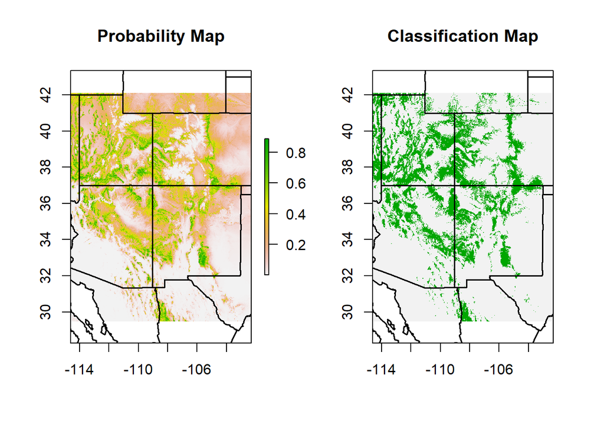

```r
   range.pdom_GAM <- crop(rang.probGAM, pied.range.bufR)
  range.cdom_GAM <- crop(rang.clasGAM, pied.range.bufR)

# giggle plots
  par(mfrow = c(1, 2))
  plot(rang.probGAM, legend = T, axes = T, main = "Probability Map") # plot clipped probability map
  plot(sf::st_geometry(states), add = T, lwd = 1.5) # add state boundaries
  plot(rang.clasGAM, legend = F, axes = T, main = "Classification Map") # plot clipped classified map
  plot(sf::st_geometry(states), add = T, lwd = 1.5)  # add state boundaries
```

```r
  par(mfrow = c(1, 1))

  GAMmaps_EX08 <- recordPlot()
```

## Question #6

- Save your data as R objects:
  - Accuracy metrics as a dataframe;
  - Classification threshold as a stand–alone scalar
  - Both prediction maps as **`.img`** format
- Save these R objects in a **`.RData`** file

These data will be used again in Module 10, Ensemble Models.

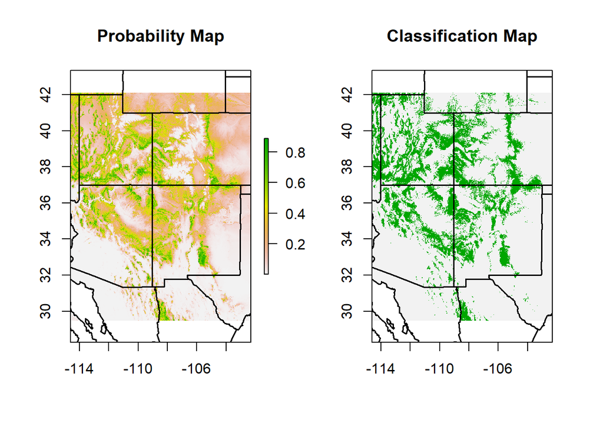

```r
setwd(path.mod5.2)
# Accuracy metrics as a dataframe
all.acc_EX08 <- all.acc

# Classification threshold as a stand--alone scalar
mod.cut.EX08 <- mod.cut[[2]]

#plot - also saved this manually
GAMmaps_EX08
```

```r
save(all.acc_EX08, mod.cut.EX08, GAMmaps_EX08, file = "range.GAM_EX08.RData")
```